# Group Final Report

Group 10: Coffee Pizza Club • 4/20/2026

[figure not shown]

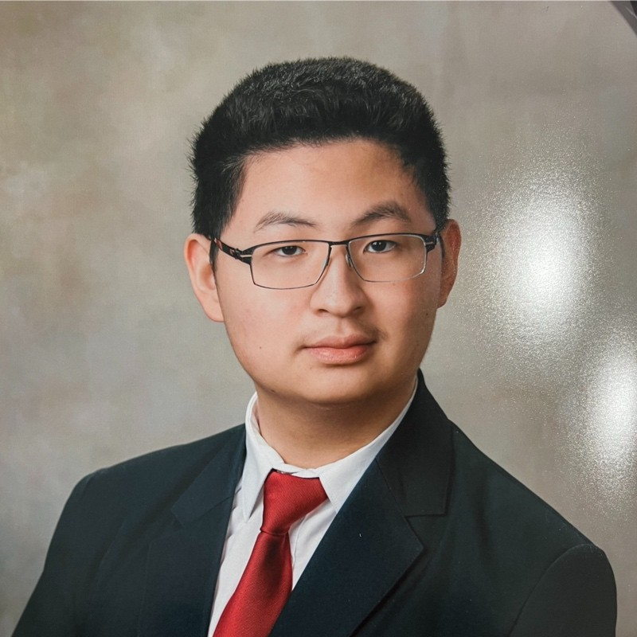

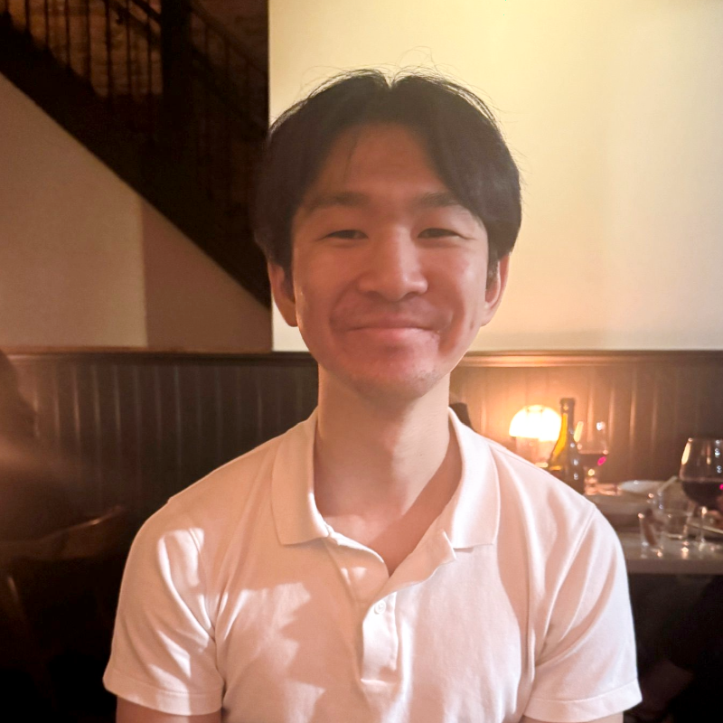

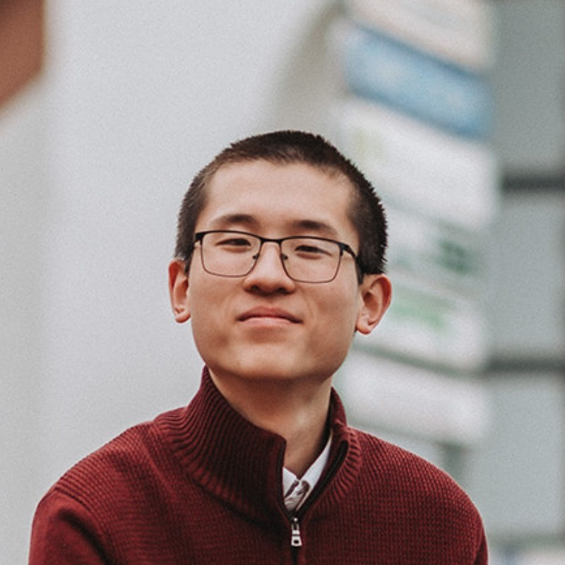

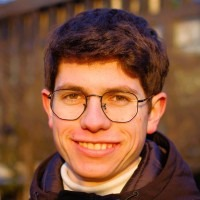

**[Riccardo Ferrari](https://www.linkedin.com/in/riccardo-ferrari-2929b722a/)**  
Financial Analyst

**[Mike Ye](https://www.linkedin.com/in/mike-ye-460923270/)**  
Team Lead

**Daniel Myung**  
Data Scientist

**[Steven Liu](https://www.linkedin.com/in/steven-liu-554652244/)**  
Communication Specialist

**[Andrea Demelas](https://www.linkedin.com/in/andreademelas/)**  
Business Analyst

# Executive Summary

414 Insurance’s dataset with depression data can reveal key characteristics as early mental illness predictors. Being able to quickly identify at-risk patients is an important priority for 414 Insurance, as it leads to preventions of the most extreme mental illness scenarios.

We use data-forward methodologies to assess mental illness patterns, recommending a targeted approach to predict onset of mental illness. Our approach utilizes supervised and unsupervised algorithmic learning models to find target characteristics. We demonstrate our work with each type of algorithm to propose the most effective strategy for identifying and preventing onset of mental illness.

# Background

Depression–characterized by symptoms ranging from persistent low mood, loss of interest, sucidial thoughts– is a common, clinically significant, and expensive medical condition for insurers. According to a Gallup poll, 3 in 10 US adults have been diagnosed with depression at some point in their lives ([Gallup](https://news.gallup.com/poll/505745/depression-rates-reach-new-highs.aspx)). In colleges across the US, 37% of the student population reported moderate to severe depressive symptoms in 2025 ([University of Michigan](https://sph.umich.edu/news/2025posts/college-student-mental-health-third-consecutive-year-improvement.html)).

While there’s a perception of depression as a benign issue, depression can cause difficulty maintaining relationships, work, or self-care. This causes it to compound into other chronic conditions, which increases total medical spending. In fact, 414 Insurance sees a 73% difference–a difference of $763– between insurees with and without depression ([Health System Tracker](https://www.healthsystemtracker.org/brief/privately-insured-people-with-depression-and-anxiety-face-high-out-of-pocket-costs/)).

Therefore, identifying high-risk members earlier opens an opportunity to target interventions before costs escalate ([Greenberg et al](https://pmc.ncbi.nlm.nih.gov/articles/PMC10499687/)).

# Technical Analysis & Model Modules

The following links provide the detailed technical breakdown of our data processing and modeling pipeline.

# 1. Data Preparation and Exploration

## Main

The first phase of the analysis focuses on preparing the data for modeling. The raw dataset is imported from a CSV file and a random 10% sample is drawn to reduce computational burden. The Name column is removed as it carries no predictive value, and all character variables are coerced to factors. A preliminary inspection of the data structure and summary statistics is then performed. The cleaned dataset is subsequently saved as an RDS file for reproducibility.

- Main Data Cleaning

## Initial Training and Testing Split

In the second file, the cleaned data is split into training and test sets following two parallel pipelines. The first preserves the original factor structure for tree-based models. The second converts the data into a fully dummy-encoded and min-max normalized format, suitable for distance- and gradient-based models such as KNN, ANN, and SVM. Both pipelines use a 50/50 split with the same random seed to ensure comparability across models.

- Initial Training and Testing Split

# 2. Supervised Learning Models

- Generalized Linear Model (GLM) for Depression

- K-Nearest Neighbors (kNN) Analysis

- Decision Tree and Random Forest Results

- Support Vector Machine (SVM) Classification

- Artificial Neural Network (ANN) & Confusion Matrix

# 3. Ensemble Methods & Final Predictions

## Overview of Stacked Model Approach

The stacked model belongs to the family of stacked generalization (ensemble techniques) where a super‑learner (here, a decision tree) learns to combine base‑learner predictions in a way that can outperform any single model, strengthened by incorporating a cost matrix.

In practice, each base model first generates a prediction vector on the test set, and then these predictions are coalesced into a single data frame along with the true response to create a new, smaller feature space for the second‑level model.

### What is a cost matrix?

In addition to combining the predictions of the five base models, the stacked model incorporates a **cost matrix** into the second‑level decision tree.

In our context, falsely predicting that a non-depressed client is depressed (a false positive) may be an overuse of mental resources, while missing a depressed client (a false negative) creates large costs for 414 Insurance down the road.

By assigning a penalty each misclassification, a cost matrix helps the decision tree optimize for a cost‑sensitive error tradeoff.

## Kappa Analysis: Stacked Model

- Combined Probabilities

Here we combined the individual probability predictions from each of the models. Later on we use decision trees as the second layer of our stacked model. By taking the individual probabilities from each of the models and combining them, we create a dataset that allows the second layer to learn from.

- Secondary Data Partitioning

Here we took the combined probabilities from the models, and created a 70 30 split to train and test our stacked models on.

- Stacked Model Architecture
- Final Stacked Model Predictions

# 4. Interactive Tools

Our ensemble model is hosted as a web application for real-time risk assessment.

[Launch Interactive Prediction Portal](https://j33c4y-daniel-myung.shinyapps.io/Interactive/)

## Financial analysis

Although the statistical performance of our models are significant, the true measure of their efficacy is in their financial performance. More specifically, we define this to be the amount of money the models will save 414 insurance compared to the base line of labeling all patients as non-depressed.

To ensure that this analysis is as accurate as possible, we have created the following cost matrix from real world data:

- **False Negative** (the model missed a depressed patient)……………………….**Cost**: $800
- **False Positive** (incorrectly labeled a non-depressed patient as depressed)….**Cost**: $251
- **True Negative** (correctly identified a non-depressed patient)…………………**Cost**: $0
- **True Positive** (correcting predicting a depressed patient)…………………….**Savings**: $549

More specically, we found a difference of $763 between non-depressed patient spending and depressed patient spending (Health System Tracking). We rounded to $800 to account for economic burden. We found the savings from therapy and costs of depression from [Statista](https://www.statista.com/statistics/1481121/depression-cost-and-potential-savings-with-pat-in-the-us-and-europe/) (249,000 and 366,600).

We created a savings-to-cost ratio using the Statista data. Solving according to the cost difference from Health System Tracking, we found a savings of $549. We use this savings to solve for the missing cost of providing mental health resources (800 - x = 549), which is $251.

Previously, we have set the classification thresholds (the lowest probability required to label an individual as “depressed”) for each model to maximize their statistical performance, specially the kappa value. However, in a real world use case, the target we should optimize for changes to finiacial impact instead. Therefore, we have re-calibrated the classification thresholds for all models except for the stack model to maximize their performance, and our results are shown in the figures below. Note that since the stack models are predicting a smaller portion of the dataset, their financial impacts needed to be scaled accordingly to make this comparison useful.

Financial Impact vs. Baseline (Relative)

| Model | TP | FP | FN | TN | Net_Impact | Precision |
| --- | --- | --- | --- | --- | --- | --- |
| Baseline | 0 | 0 | 6721 | 13967 | 0 | 0.00 |
| Logistic Regression | 6721 | 13967 | 0 | 0 | 5560912 | 32.49 |
| KNN | 2149 | 4500 | 4572 | 9467 | 1769501 | 32.32 |
| ANN | 1972 | 4797 | 4749 | 9170 | 1456181 | 29.13 |
| Decision Tree (C5.0) | 6721 | 13967 | 0 | 0 | 5560912 | 32.49 |
| Best SVM | 6721 | 13967 | 0 | 0 | 5560912 | 32.49 |
| LogReg (opt) | 6721 | 13967 | 0 | 0 | 5560912 | 32.49 |
| KNN (opt) | 6653 | 13842 | 68 | 125 | 5500555 | 32.46 |
| ANN (opt) | 6721 | 13967 | 0 | 0 | 5560912 | 32.49 |
| C5.0 (opt) | 6721 | 13967 | 0 | 0 | 5560912 | 32.49 |
| SVM (opt) | 6721 | 13967 | 0 | 0 | 5560912 | 32.49 |
| Stacked (C5.0) | 1506 | 2763 | 431 | 1507 | 5165281 | 35.28 |
| Stacked (RF) | 209 | 321 | 1728 | 3949 | 4028570 | 39.43 |

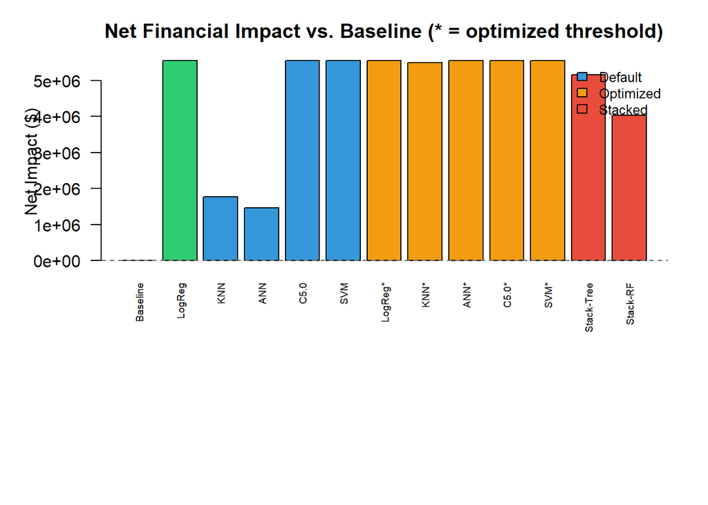

This unique situation is likely due to the extremely high **cost** of a misdiagnosing a depression prone customer ($800) and the high **benefit** ($549) of diagnosing a depression prone patient correctly. This, when combined with the skewed dataset, with 32.5% of the data points being depressed patients, meant that classifying everyone as depressed benefits from the high benefit of a true positive and the low costs of a false positive.

# Conclusion

In conclusion, the stacked model is the most realistic direction for future work because it better reflects how this problem would be handled in practice, even though the GLM has the most financial impact. Rather than relying on a single classifier, the stacked approach combines the strengths of multiple models and uses a second-layer learner to make a more flexible and potentially less biased decision.

The stacked framework also has the advantage of longevity. As new interventions are introduced and the available resources change, the model can be retrained so its decision rules stay aligned with current conditions. In brief, the stacked model is a more adaptable foundation for future updates, making it the most realistic long-term option for this project.